# MICOM - wastewateR Worksheet Answer Key

### 8.

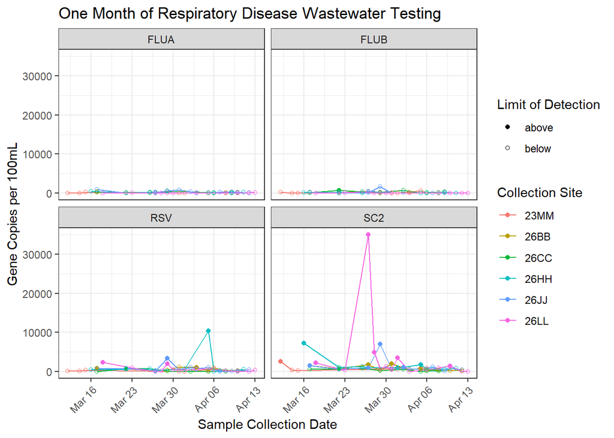

```r
# make a chart

ggplot() +
  geom_line(data = gc_calc_one_value, aes(x = sample_collection_date, y = mean_gc_per_100mL, color = collection_site)) +
  geom_point(data = gc_calc_one_value, aes(x = sample_collection_date, y = mean_gc_per_100mL, shape = relative_lod, color = collection_site)) +
  scale_shape_manual(values = c("above" = 16, "below" = 1)) +
  theme_bw() +
  labs(x = "Sample Collection Date",
       y = "Gene Copies per 100mL",
       shape = "Limit of Detection",
       color = "Collection Site",
       title = "One Month of Respiratory Disease Wastewater Testing") +
  theme(axis.text.x = element_text(angle = 45, vjust = 1, hjust=1)) +
  facet_wrap(.~Target)
```

# Bonus Section! Displaying Data as Concentration per uL

### 1.

```r
# read in our data
all_data <- read.csv(paste0(comp_data_loc, "post_process_compiled.csv"))
```

### 2.

```r
# select the negative control well data
neg_controls <- filter(all_data, grepl("NEG", Sample))

# keep only the necessary columns for use in calculate_lod_invgamm()
neg_controls <- neg_controls %>% select(Sample, Target, plate_name, Positives, AcceptedDroplets)
```

### 3.

```r
# create a plate_date column that corresponds to when the plate was run/generated
neg_controls <- neg_controls %>% mutate(plate_date = as.POSIXct(substr(x = plate_name, start = 1, stop = 8), format = "%m.%d.%y"))
```

### 4.

```r
# reorder the columns
neg_controls <- neg_controls %>% select(Sample, Target, plate_name, plate_date, Positives, AcceptedDroplets)

# rename the columns
colnames(neg_controls) <- c("Sample", "Target", "plate", "plate_date", "Positives", "AcceptedDroplets")
```

### 5.

```r
lod_df <- calculate_lod_invgamm(neg_controls)
```

### 6.

```r
# merge sample data from multiples to 1 value

merged_all <- merging_methods(all_data, method = "average")

# create bridge table

bridge_table <- all_data %>% select(Sample, Target, plate_name) %>% distinct()
```

### 7.

```r
# join lod_df onto this merged dataset
step_one <- merge(merged_all, bridge_table, by = c("Sample", "Target"))

final_conc_set <- merge(step_one, lod_df, by.x = c("plate_name", "Target"), by.y = c("plate", "Target"))
```

### 8.

```r
# make indicator column
final_conc_set <- final_conc_set %>% mutate(relative_lod = case_when(Concentration > NEG_limit_final ~ "above",
                                                         T ~ "below"))
```

### 9.

```r
# get site and date
final_conc_set <- final_conc_set %>%
mutate(sample_collection_date = as.POSIXct(substr(Sample, 5, 10), format = "%y%m%d"),
       collection_site = substr(Sample, 1, 4))
```

### 10.

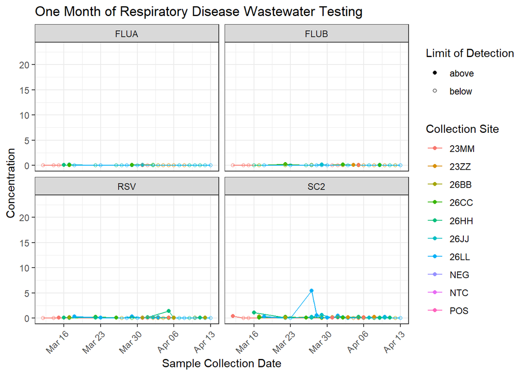

```r
# make ggplot
ggplot() +
  geom_line(data = final_conc_set, aes(x = sample_collection_date, y = Concentration, color = collection_site)) +
  geom_point(data = final_conc_set, aes(x = sample_collection_date, y = Concentration, shape = relative_lod, color = collection_site)) +
  scale_shape_manual(values = c("above" = 16, "below" = 1)) +
  theme_bw() +
  labs(x = "Sample Collection Date",
       y = "Concentration",
       shape = "Limit of Detection",
       color = "Collection Site",
       title = "One Month of Respiratory Disease Wastewater Testing") +
  theme(axis.text.x = element_text(angle = 45, vjust = 1, hjust=1)) +
  facet_wrap(.~Target)
```

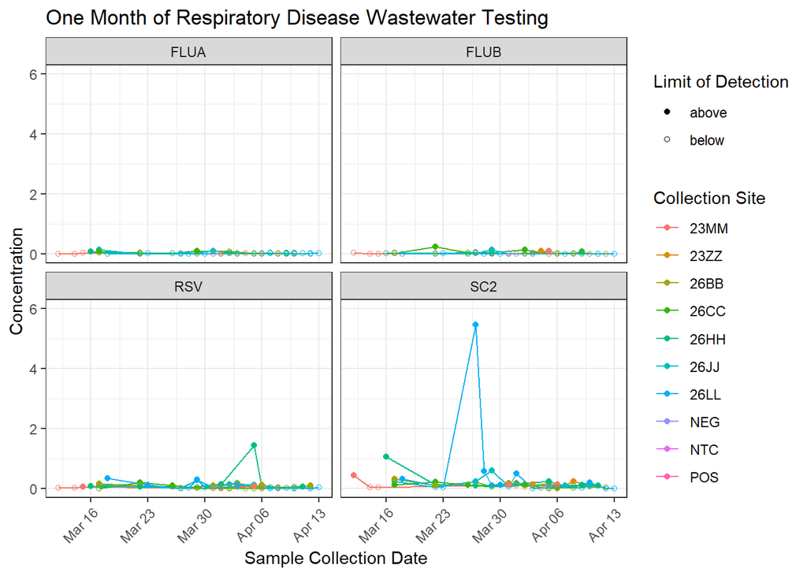

```r
# make ggplot
ggplot() +
  geom_line(data = final_conc_set, aes(x = sample_collection_date, y = Concentration, color = collection_site)) +
  geom_point(data = final_conc_set, aes(x = sample_collection_date, y = Concentration, shape = relative_lod, color = collection_site)) +
  scale_shape_manual(values = c("above" = 16, "below" = 1)) +
  coord_cartesian(ylim = c(0, 6)) +
  theme_bw() +
  labs(x = "Sample Collection Date",
       y = "Concentration",
       shape = "Limit of Detection",
       color = "Collection Site",
       title = "One Month of Respiratory Disease Wastewater Testing") +
  theme(axis.text.x = element_text(angle = 45, vjust = 1, hjust=1)) +
  facet_wrap(.~Target)
```

### Bonus comparison:

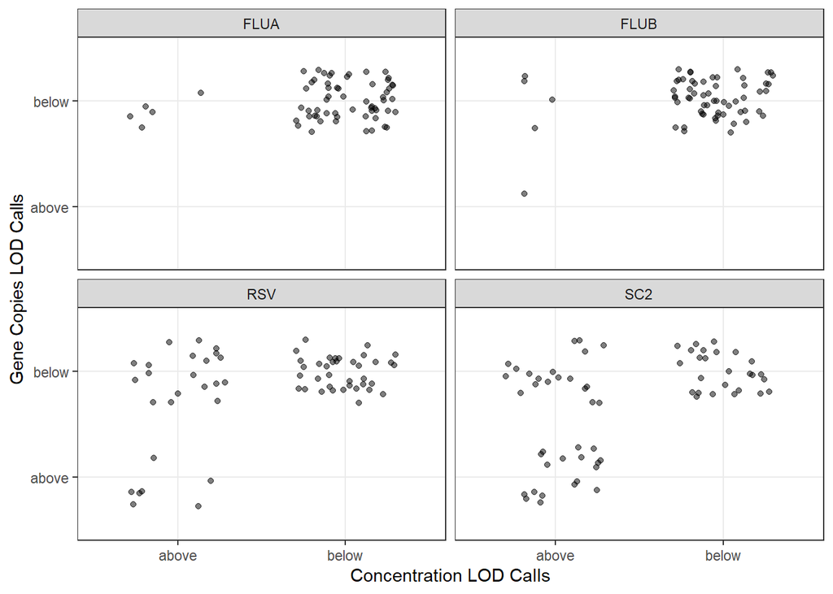

```r
# final_conc_set vs. gc_calc_one_value

final_conc_set_slim <- final_conc_set %>% select(Sample, Target, relative_lod)

colnames(final_conc_set_slim) <- c("Sample", "Target", "conc_lod")

gc_calc_one_value_slim <- gc_calc_one_value %>% ungroup() %>% select(Sample, Target, relative_lod)

colnames(gc_calc_one_value_slim) <- c("Sample", "Target", "gc_lod")

all_lod_compare <- merge(final_conc_set_slim, gc_calc_one_value_slim, by = c("Sample", "Target"))

ggplot() +
  geom_jitter(data = all_lod_compare, aes(x = conc_lod, y = gc_lod), alpha = 0.5, width = 0.3, height = 0.3) +
  theme_bw() +
  labs(x = "Concentration LOD Calls",
       y = "Gene Copies LOD Calls") +
  facet_wrap(.~Target)
```

- There are never instances where the Concentration LOD call is “below” and the Gene Copies LOD call is “above”
- There are instances where the Concentration LOD call is “above” and the Gene Copies LOD call is “below”

The two above points imply that the Gene Copies LOD calls are more conservative than the Concentration LOD calls.

*This answer key was created by the Michigan Public Health Integrated Center for Outbreak Analytics and Modeling (MICOM) in partnership with the Wigginton-Eisenberg Laboratory.*

*This work was made possible by cooperative agreement CDC-RFA-FT-23-0069 from the CDC’s Center for Forecasting and Outbreak Analytics. Its contents are solely the responsibility of the authors and do not necessarily represent the official views of the Centers for Disease Control and Prevention.*